# Empirical Project #1 - The OHP Experiment

```r
# Loading packages
pacman::p_load(ggplot2, stargazer, dplyr, magrittr,
               knitr)
```

```r
# Reading the data
ohp <- haven::read_dta("data/ohp.dta")
```

# *Question 1:*

Explain the difference between the variables `treatment` and `ohp_all_ever_survey`. Explain why treatment is the treatment variable (Di), rather than `ohp_all_ever_survey`

The variable `treatment` is the treatment variable because the purpose of the study is to see the difference in observable health outcomes between those with the free coverage offered by OHP and those who are not given such benefits.

The variable `ohp_all_ever_survey` is not considered to be the treatment because it is not the variable that is being manipulated by the research designer for the experiment. It is still important to consider, however, because it will give us insight into compliance rates in the sample and will better illustrate the true treatment effect.

# *Question 2:*

Provide evidence that the OHP lottery really did randomly assign individuals to treatment and control groups. Similar to Table 1 in Taubman et al. (2014), please create a nicely formatted table that reports means of 4 to 6 relevant characteristics for individuals in the control group.

Note: Part of this question is to get you to think about which variables should be balanced in a randomized experiment. You need to read carefully through all the variables in the data set (documentation attached at the end of this file) and decide which 4 to 6 you will summarize.

```r
# Converting values to numeric
ohp = data.frame(lapply(
  ohp, function(x) as.numeric(as.character(x))))

# Creating intervals for different age ranges
ohp %<>%
  mutate(age_interval = cut(ohp$age_inp,breaks = seq(0,80,by=10),na.rm=T))

# Converting variables to factors
ohp %<>% mutate(treatment = as.factor(treatment),
               ohp_all_ever_survey = as.factor(ohp_all_ever_survey),
               gender_inp = as.factor(gender_inp))
```

The variables summarized in the table below were deemed as important considerations for ensuring a proper balance between the treatment and control groups. The `age` variable was selected because age plays a significant role in the demand for healthcare. Spending on healthcare for young people is [considerably less](http://web.archive.org/web/20160325101526/https://www.cms.gov/research-statistics-data-and-systems/statistics-trends-and-reports/nationalhealthexpenddata/nhe-fact-sheet.html) than healthcare spending on the elderly and could potentially skew the interpretation of the data if not properly considered.

`Gender` was selected in order to account for differences in gender and trends in healthcare usage. [Some studies](https://pubmed.ncbi.nlm.nih.gov/10718692/#:~:text=Background%3A%20Studies%20have%20shown%20that,health%20care%20services%20than%20men.) suggest women tend to use healthcare services at higher rates than men. Therefore, including this variable in our consideration can help to remove and differences that may naturally exist prior to the treatment.

```r
library(expss)

ohp %>% apply_labels(.,
                     treatment=c("Treatment"=1,
                                 "Control"=0),
                     age_inp="Age",
                     gender_inp="Gender",
                     dep_dx_pre_lottery="Depression Diagnosis (pre-lottery)",
                     dia_dx_pre_lottery="Diabetes Diagnosis (pre-lottery)",
                     hbp_dx_pre_lottery=
                       "High Blood Pressue/Hypertension (pre-lottery)") %>%
    tab_cells(age_inp,gender_inp,
              dep_dx_pre_lottery,dia_dx_pre_lottery,hbp_dx_pre_lottery) %>%
    tab_cols(total(), treatment) %>%
    tab_stat_mean_sd_n() %>%
    tab_pivot()
```

|  | #Total |  | treatment Control | treatment Treatment |
| --- | --- | --- | --- | --- |
| Age |  |  |  |  |
| Mean | 40.8 |  | 40.6 | 41.0 |
| Std. dev. | 11.7 |  | 11.7 | 11.7 |
| Unw. valid N | 12228.0 |  | 5841.0 | 6387.0 |
| Gender |  |  |  |  |
| Mean |  |  |  |  |
| Std. dev. | 0.5 |  | 0.5 | 0.5 |
| Unw. valid N | 12229.0 |  | 5842.0 | 6387.0 |
| Depression Diagnosis (pre-lottery) |  |  |  |  |
| Mean | 0.3 |  | 0.4 | 0.3 |
| Std. dev. | 0.5 |  | 0.5 | 0.5 |
| Unw. valid N | 12229.0 |  | 5842.0 | 6387.0 |
| Diabetes Diagnosis (pre-lottery) |  |  |  |  |
| Mean | 0.1 |  | 0.1 | 0.1 |
| Std. dev. | 0.3 |  | 0.3 | 0.3 |
| Unw. valid N | 12229.0 |  | 5842.0 | 6387.0 |
| High Blood Pressue/Hypertension (pre-lottery) |  |  |  |  |
| Mean | 0.2 |  | 0.2 | 0.2 |
| Std. dev. | 0.4 |  | 0.4 | 0.4 |
| Unw. valid N | 12229.0 |  | 5842.0 | 6387.0 |

# *Question 3:*

For each of the variables you summarized above, calculate: - the difference between the mean in the treatment group and the mean in the control group; - the standard error for the difference in means

```r
glm(data = ohp, formula = treatment ~ age_inp + gender_inp +
      dep_dx_pre_lottery+dia_dx_pre_lottery+hbp_dx_pre_lottery,
    family=binomial) -> mod1
summary(mod1)
```

```
##
## Call:
## glm(formula = treatment ~ age_inp + gender_inp + dep_dx_pre_lottery +
##     dia_dx_pre_lottery + hbp_dx_pre_lottery, family = binomial,
##     data = ohp)
##
## Deviance Residuals:
##    Min      1Q  Median      3Q     Max
## -1.268  -1.214   1.103   1.140   1.197
##
## Coefficients:
##                      Estimate Std. Error z value Pr(>|z|)
## (Intercept)         -0.009687   0.070970  -0.136   0.8914
## age_inp              0.003377   0.001645   2.053   0.0401 *
## gender_inp1         -0.009013   0.037122  -0.243   0.8082
## gender_inp2        -10.683447 119.468055  -0.089   0.9287
## dep_dx_pre_lottery  -0.082268   0.039266  -2.095   0.0362 *
## dia_dx_pre_lottery  -0.017227   0.073527  -0.234   0.8148
## hbp_dx_pre_lottery  -0.022913   0.051171  -0.448   0.6543
## ---
## Signif. codes:  0 '***' 0.001 '**' 0.01 '*' 0.05 '.' 0.1 ' ' 1
##
## (Dispersion parameter for binomial family taken to be 1)
##
##     Null deviance: 16927  on 12227  degrees of freedom
## Residual deviance: 16917  on 12221  degrees of freedom
##   (1 observation deleted due to missingness)
## AIC: 16931
##
## Number of Fisher Scoring iterations: 9
```

```r
library(lemon)
knit_print.data.frame <- lemon_print
```

```r
tab = ohp %>% group_by(treatment) %>% na.omit() %>%
  mutate(gender_inp = as.integer(gender_inp)) %>%
  summarise(avg_age      =  mean(age_inp),
            gender_ratio =  mean(gender_inp),
            avg_hbp_dx   =  mean(hbp_dx_pre_lottery),
            avg_dep_dx   =  mean(dep_dx_pre_lottery),
            avg_dia_dx   =  mean(dia_dx_pre_lottery))%>%
  add_row(treatment="..Standard Deviation") %>%
  add_row(treatment=".....Difference in Means") %>%
  add_row(treatment=".....Difference in St.Dev")%>%
  add_row(treatment="..Standard Deviation", .before = 2)

# Defining sd calculations
tab[2,2]= ohp %>% filter(treatment==0) %>% na.omit() %>%
  summarise(sd(age_inp))
tab[2,3]= ohp %>% filter(treatment==0) %>% na.omit() %>%
  mutate(gender_inp = as.numeric(gender_inp)) %>%
  summarise(sd(gender_inp))
tab[2,4]= ohp %>% filter(treatment==0) %>% na.omit() %>%
  summarise(sd(hbp_dx_pre_lottery))
tab[2,5]= ohp %>% filter(treatment==0) %>% na.omit() %>%
  summarise(sd(dep_dx_pre_lottery))
tab[2,6]= ohp %>% filter(treatment==0) %>% na.omit() %>%
  summarise(sd(dia_dx_pre_lottery))

tab[4,2]= ohp %>% filter(treatment==1) %>% na.omit() %>%
  summarise(sd(age_inp))
tab[4,3]= ohp %>% filter(treatment==1) %>% na.omit() %>%
  mutate(gender_inp = as.numeric(gender_inp)) %>%
  summarise(sd(gender_inp))
tab[4,4]= ohp %>% filter(treatment==1) %>% na.omit() %>%
  summarise(sd(hbp_dx_pre_lottery))
tab[4,5]= ohp %>% filter(treatment==1) %>% na.omit() %>%
  summarise(sd(dep_dx_pre_lottery))
tab[4,6]= ohp %>% filter(treatment==1) %>% na.omit() %>%
  summarise(sd(dia_dx_pre_lottery))


# Defining differences in means
tab[5,2]= (tab[1,2]) - (tab[3,2])
tab[5,3]= (tab[1,3]) - (tab[3,3])
tab[5,4]= (tab[1,4]) - (tab[3,4])
tab[5,5]= (tab[1,5]) - (tab[3,5])
tab[5,6]= (tab[1,6]) - (tab[3,6])

# Defining differences in sd's
tab[6,2]= (tab[2,2]) - (tab[4,2])
tab[6,3]= (tab[2,3]) - (tab[4,3])
tab[6,4]= (tab[2,4]) - (tab[4,4])
tab[6,5]= (tab[2,5]) - (tab[4,5])
tab[6,6]= (tab[2,6]) - (tab[4,6])


tab[1,1]="Treatment - Mean"
tab[3,1]="Control   - Mean"
    # Printing results
tab
```

[output not shown]

# *Question 4:*

Is the balance table consistent with individuals having been randomly assigned to treatment group and control groups? Why or why not?

```r
df = ohp %>%
  group_by(treatment) %>%
  mutate(treatment = as.factor(treatment))%>%
  na.omit()%>%
  summarise(plyr::count(age_inp)) %>% ungroup()
```

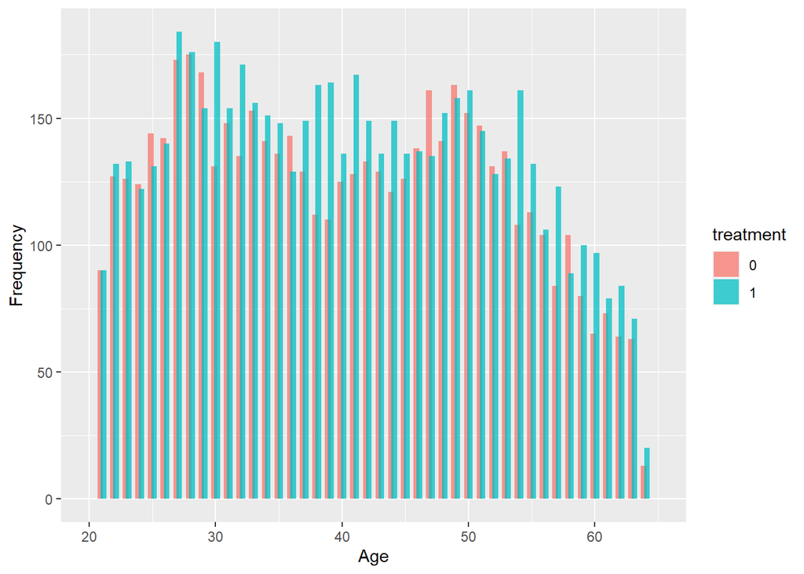

```r
ggplot(df,aes(x = x, y = freq,fill=treatment)) +
  geom_bar(stat = "identity", position = position_dodge(width = 0.5),
           alpha=.75) + xlab("Age") + ylab("Frequency") + xlim(20,65)
```

More formally, we can quantify whether this means that there is *true* randomization with myriad of different tests. We can challenge our null and alternative hypotheses by using pre-written packages in `R`. With the calculated p-value below, we can reject our alternative hypothesis of non-randomness of age.

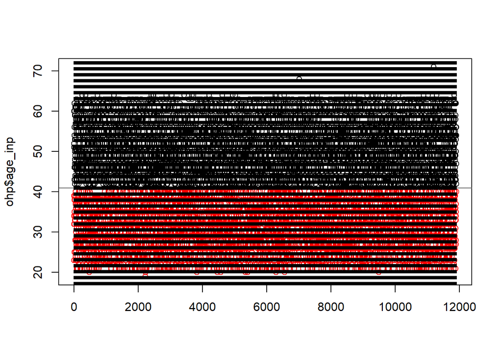

```
##
##  Runs Test
##
## data:  ohp$age_inp
## statistic = 0.38313, runs = 5975, n1 = 5836, n2 = 6075, n = 11911,
## p-value = 0.7016
## alternative hypothesis: nonrandomness
```

```r
randtests::runs.test(ohp$age_inp,plot=T)
```

```r
t.test(dep_dx_pre_lottery ~ treatment, data = ohp)
```

```
##
##  Welch Two Sample t-test
##
## data:  dep_dx_pre_lottery by treatment
## t = 2.1317, df = 12101, p-value = 0.03305
## alternative hypothesis: true difference in means between group 0 and group 1 is not equal to 0
## 95 percent confidence interval:
##  0.001472331 0.035124280
## sample estimates:
## mean in group 0 mean in group 1
##       0.3502225       0.3319242
```

# *Question 5:*

Estimate the compliance rate for the OHP experiment. That is, what is the effect of being assigned to the treatment group on the probability of being enrolled in Medicaid?

If *compliance rate* is defined as the fraction of the treatment group units receiving treatment minus the fraction of control group units reviving treatment, we can calculate the rate as follows:

```r
# Fraction of treatment group reciving treatment
treat_total = ohp %>% filter(treatment==1) %>% count()
treat_comp  = ohp %>% filter(treatment==1 & ohp_all_ever_survey==1) %>% count()
treat_rec_treat = treat_comp/treat_total

# Fraction of control group reciving treatment
ctrl_total = ohp %>% filter(treatment==0) %>% count()
ctrl_comp  = ohp %>% filter(treatment==0 & ohp_all_ever_survey==1) %>% count()
ctrl_rec_treat = ctrl_comp/ctrl_total

compl_rate = treat_rec_treat - ctrl_rec_treat #  = compliance rate
compl_rate
```

```
##           n
## 1 0.2535943
```

# *Question 6 & 7:*

- What is the intent-to-treat (ITT) effect of the OHP experiment on health outcomes? Please create a nicely formatted table that reports ITT estimates on 4 to 6 relevant health outcomes. Again, part of this question is to get you to think about which 4 to 6 variables could be used as health outcome variables.
- What is the “treatment on the treated” effect (ATET) of the OHP experiment, i.e. the effect among those who applied for Medicaid? Estimate it for every health outcome you chose in question 6 and provide some intuition for the calculation of this estimate.

```r
tab2 = ohp %>% group_by(treatment) %>% na.omit() %>%
  summarise(avg_dia = mean(dia_dx_post_lottery),
            avg_dep = mean(dep_dx_post_lottery),
            avg_rx  = mean(rx_num_mod_inp),
            avg_doc = mean(doc_num_mod_inp))%>%
  add_row(treatment="..... Raw Difference (ITT)") %>%
  add_row(treatment="..... Divided by Compliance Rate (ATET)")

# Setting value calculations
  ## ITT
tab2[3,2]= tab2[2,2]-tab2[1,2]
tab2[3,3]= tab2[2,3]-tab2[1,3]
tab2[3,4]= tab2[2,4]-tab2[1,4]
tab2[3,5]= tab2[2,5]-tab2[1,5]
  ## ATET
tab2[4,2]= tab2[3,2]/compl_rate
tab2[4,3]= tab2[3,3]/compl_rate
tab2[4,4]= tab2[3,4]/compl_rate
tab2[4,5]= tab2[3,5]/compl_rate

tab2
```

| treatment | avg_dia | avg_dep | avg_rx | avg_doc |
| --- | --- | --- | --- | --- |
| 0 | 0.0114497 | 0.0494922 | 1.7724838 | 5.6472761 |
| 1 | 0.0204426 | 0.0535563 | 1.8944078 | 6.0662274 |
| ….. Raw Difference (ITT) | 0.0089930 | 0.0040642 | 0.1219240 | 0.4189513 |
| ….. Divided by Compliance Rate (ATET) | 0.0354620 | 0.0160264 | 0.4807837 | 1.6520534 |

```r
# Trimming our data set
ohp2 = ohp %>% group_by(treatment) %>%
  select(c(
    "treatment",
    "dia_dx_post_lottery",
    "hbp_dx_post_lottery",
    "rx_num_mod_inp",
    "doc_num_mod_inp",
    "dep_dx_post_lottery"))

star_mod1 = lm(data = ohp2, formula = dia_dx_post_lottery~
     treatment+
     hbp_dx_post_lottery+
     rx_num_mod_inp+
     doc_num_mod_inp+
     dep_dx_post_lottery+
     dia_dx_post_lottery)
star_mod2 = lm(data = ohp2, formula = hbp_dx_post_lottery~
     treatment+
     hbp_dx_post_lottery+
     rx_num_mod_inp+
     doc_num_mod_inp+
     dep_dx_post_lottery+
     dia_dx_post_lottery)
star_mod3 = lm(data = ohp2, formula = rx_num_mod_inp~
     treatment+
     hbp_dx_post_lottery+
     rx_num_mod_inp+
     doc_num_mod_inp+
     dep_dx_post_lottery+
     dia_dx_post_lottery)
star_mod4 = lm(data = ohp2, formula = doc_num_mod_inp~
     treatment+
     hbp_dx_post_lottery+
     rx_num_mod_inp+
     doc_num_mod_inp+
     dep_dx_post_lottery+
     dia_dx_post_lottery)
star_mod5 = lm(data = ohp2, formula = dep_dx_post_lottery~
     treatment+
     hbp_dx_post_lottery+
     rx_num_mod_inp+
     doc_num_mod_inp+
     dep_dx_post_lottery+
     dia_dx_post_lottery)
stargazer::stargazer(star_mod2,star_mod3,star_mod4,
                     star_mod5,star_mod1,type = "html",
                     colnames  = FALSE,
                     column.labels = c("Hypertension",
                                       "Prescriptions",
                                       "Doctor Visits",
                                       "Depression",
                                       "Diabetes"))
```

|  | *Dependent variable:* |  |  |  |  |
| --- | --- | --- | --- | --- | --- |
|  | hbp_dx_post_lottery | rx_num_mod_inp | doc_num_mod_inp | dep_dx_post_lottery | dia_dx_post_lottery |
|  | Hypertension | Prescriptions | Doctor Visits | Depression | Diabetes |
|  | (1) | (2) | (3) | (4) | (5) |
| treatment1 | -0.002 | 0.055 | 0.249 | 0.003 | 0.008*** |
|  | (0.004) | (0.049) | (0.208) | (0.004) | (0.002) |
| rx_num_mod_inp | 0.006*** |  | 1.459*** | 0.003*** | 0.006*** |
|  | (0.001) |  | (0.037) | (0.001) | (0.0004) |
| hbp_dx_post_lottery |  | 0.810*** | 1.230*** | 0.047*** | 0.055*** |
|  |  | (0.106) | (0.453) | (0.009) | (0.005) |
| doc_num_mod_inp | 0.001*** | 0.081*** |  | 0.002*** | -0.0002* |
|  | (0.0002) | (0.002) |  | (0.0002) | (0.0001) |
| dep_dx_post_lottery | 0.052*** | 0.432*** | 3.851*** |  | 0.002 |
|  | (0.010) | (0.111) | (0.472) |  | (0.005) |
| dia_dx_post_lottery | 0.187*** | 2.717*** | -1.605* | 0.005 |  |
|  | (0.017) | (0.194) | (0.833) | (0.016) |  |
| Constant | 0.038*** | 1.219*** | 2.822*** | 0.032*** | -0.001 |
|  | (0.003) | (0.038) | (0.165) | (0.003) | (0.002) |
| Observations | 11,450 | 11,450 | 11,450 | 11,450 | 11,450 |
| R<sup>2</sup> | 0.024 | 0.146 | 0.130 | 0.014 | 0.032 |
| Adjusted R<sup>2</sup> | 0.024 | 0.146 | 0.129 | 0.013 | 0.031 |
| Residual Std. Error (df = 11444) | 0.229 | 2.606 | 11.089 | 0.219 | 0.124 |
| F Statistic (df = 5; 11444) | 56.637*** | 392.546*** | 341.358*** | 32.139*** | 75.272*** |
| *Note:* | p<0.1; p<0.05; p<0.01 |  |  |  |  |

# *Question 8:*

Do you have to worry about attrition bias in analyzing this data? Explain why or why not?

Attrition bias is something that needs to be considered in this topic of analysis. If a person belonged to the treatment group and left halfway though the duration of the study, then the *true* effect of the treatment will be altered because we will not have the information about how the individual *would* have acted given the treatment. Instead as a result, when looking at an overview of the data and attempting to define causality, there will be a seemingly-lesser impact of the treatment that what might be the true treatment effect.

# *Question 9:*

Suppose that you are submitting these results to a general interest journal such as Science for publication. Write an abstract of 200 or fewer words describing what you have found in your analysis of the OHP data, similar to the abstract in Taubman et al. (2014).

In an analysis of data collected from the OHP experiment, various different observable health outcomes were collected for two groups of individuals, those who were selected in the lottery to be eligible for health coverage with OHP and those who were not selected (the treatment and the control, respectively).